# question3 – In God We Trust, In AI We Ask

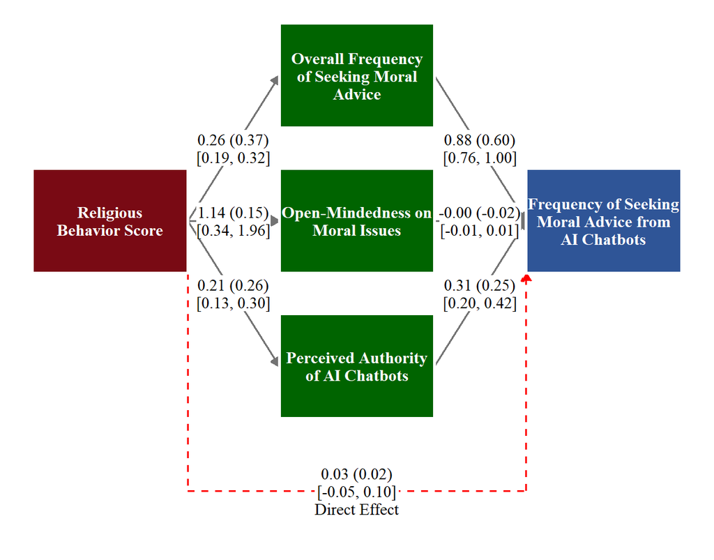

Figure 1: Study 1: Parallel Mediation Model

Table 5: Study 1: Full Parameter Estimates — Parallel Mediation

| Path | b | β | SE | 95% CI LL | 95% CI UL | p |
| --- | --- | --- | --- | --- | --- | --- |
| Religious Behavior Score → Overall Frequency of Seeking Moral Advice | 0.256 | 0.369 | 0.035 | 0.186 | 0.325 | <.001 |
| Religious Behavior Score → Open-Mindedness on Moral Issues | 1.141 | 0.146 | 0.410 | 0.342 | 1.961 | 0.005 |
| Religious Behavior Score → Perceived Authority of AI Chatbots as Moral Advisors | 0.215 | 0.262 | 0.043 | 0.130 | 0.299 | <.001 |
| Overall Frequency of Seeking Moral Advice → AI Moral Frequency | 0.882 | 0.600 | 0.064 | 0.756 | 1.003 | <.001 |
| Open-Mindedness on Moral Issues → AI Moral Frequency | -0.002 | -0.016 | 0.005 | -0.013 | 0.009 | 0.702 |
| Perceived Authority of AI Chatbots as Moral Advisors → AI Moral Frequency | 0.310 | 0.249 | 0.057 | 0.197 | 0.421 | <.001 |
| Religious Behavior Score → AI Moral Frequency (direct) | 0.026 | 0.025 | 0.040 | -0.054 | 0.103 | 0.528 |
| Overall Frequency of Seeking Moral Advice ~~ Open-Mindedness on Moral Issues | 9.059 | 0.461 | 1.101 | 6.833 | 11.161 | <.001 |
| Overall Frequency of Seeking Moral Advice ~~ Perceived Authority of AI Chatbots as Moral Advisors | 0.691 | 0.342 | 0.117 | 0.460 | 0.918 | <.001 |
| Open-Mindedness on Moral Issues ~~ Perceived Authority of AI Chatbots as Moral Advisors | 4.683 | 0.194 | 1.325 | 2.013 | 7.274 | <.001 |
| Indirect via Overall Frequency of Seeking Moral Advice | 0.226 | 0.221 | 0.037 | 0.157 | 0.302 | <.001 |
| Indirect via Open-Mindedness on Moral Issues | -0.002 | -0.002 | 0.007 | -0.016 | 0.010 | 0.720 |
| Indirect via Perceived Authority of AI Chatbots as Moral Advisors | 0.067 | 0.065 | 0.019 | 0.034 | 0.108 | <.001 |
| Total indirect effect | 0.290 | 0.284 | 0.041 | 0.210 | 0.373 | <.001 |

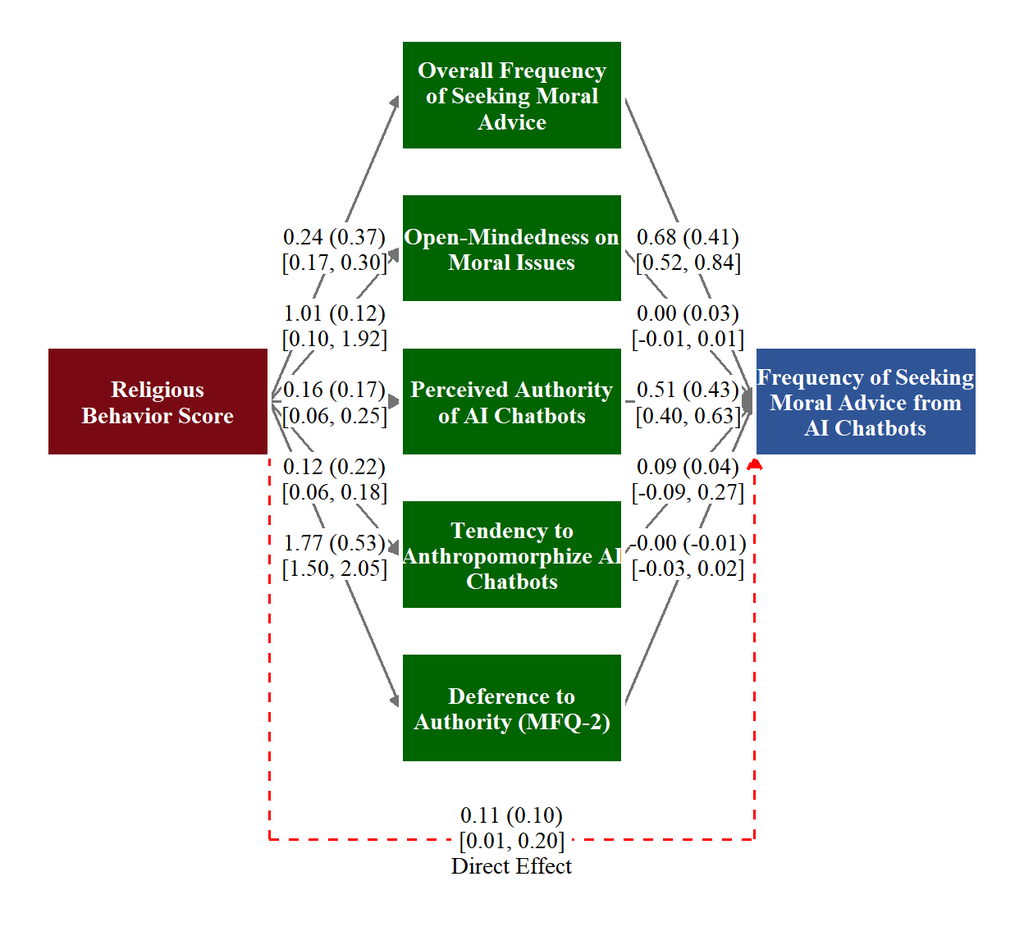

Figure 2: Study 2: Parallel Mediation Model

Table 6: Study 2: Full Parameter Estimates — Parallel Mediation

| Path | b | β | SE | 95% CI LL | 95% CI UL | p |
| --- | --- | --- | --- | --- | --- | --- |
| Religious Behavior Score → Overall Frequency of Seeking Moral Advice | 0.239 | 0.367 | 0.034 | 0.172 | 0.305 | <.001 |
| Religious Behavior Score → Open-Mindedness on Moral Issues | 1.008 | 0.117 | 0.465 | 0.100 | 1.919 | 0.030 |
| Religious Behavior Score → Perceived Authority of AI Chatbots as Moral Advisors | 0.158 | 0.175 | 0.048 | 0.062 | 0.250 | <.001 |
| Religious Behavior Score → Tendency to Anthropomorphize AI Chatbots | 0.120 | 0.223 | 0.030 | 0.062 | 0.177 | <.001 |
| Religious Behavior Score → Deference to Authority (MFQ-2) | 1.775 | 0.535 | 0.143 | 1.496 | 2.053 | <.001 |
| Overall Frequency of Seeking Moral Advice → AI Moral Frequency | 0.679 | 0.409 | 0.081 | 0.520 | 0.841 | <.001 |
| Open-Mindedness on Moral Issues → AI Moral Frequency | 0.004 | 0.032 | 0.006 | -0.007 | 0.015 | 0.474 |
| Perceived Authority of AI Chatbots as Moral Advisors → AI Moral Frequency | 0.512 | 0.429 | 0.060 | 0.396 | 0.629 | <.001 |
| Tendency to Anthropomorphize AI Chatbots → AI Moral Frequency | 0.086 | 0.043 | 0.092 | -0.093 | 0.269 | 0.349 |
| Deference to Authority (MFQ-2) → AI Moral Frequency | -0.004 | -0.011 | 0.014 | -0.032 | 0.025 | 0.798 |
| Religious Behavior Score → AI Moral Frequency (direct) | 0.106 | 0.098 | 0.050 | 0.009 | 0.205 | 0.032 |
| Overall Frequency of Seeking Moral Advice ~~ Open-Mindedness on Moral Issues | 9.482 | 0.462 | 1.130 | 7.261 | 11.710 | <.001 |
| Overall Frequency of Seeking Moral Advice ~~ Perceived Authority of AI Chatbots as Moral Advisors | 0.756 | 0.355 | 0.121 | 0.517 | 0.990 | <.001 |
| Overall Frequency of Seeking Moral Advice ~~ Tendency to Anthropomorphize AI Chatbots | 0.312 | 0.249 | 0.075 | 0.167 | 0.461 | <.001 |
| Overall Frequency of Seeking Moral Advice ~~ Deference to Authority (MFQ-2) | 1.292 | 0.193 | 0.368 | 0.587 | 2.021 | <.001 |
| Open-Mindedness on Moral Issues ~~ Perceived Authority of AI Chatbots as Moral Advisors | 9.002 | 0.298 | 1.662 | 5.764 | 12.282 | <.001 |
| Open-Mindedness on Moral Issues ~~ Tendency to Anthropomorphize AI Chatbots | 5.064 | 0.285 | 1.034 | 3.122 | 7.094 | <.001 |
| Open-Mindedness on Moral Issues ~~ Deference to Authority (MFQ-2) | 12.305 | 0.129 | 5.494 | 1.433 | 23.014 | 0.025 |
| Perceived Authority of AI Chatbots as Moral Advisors ~~ Tendency to Anthropomorphize AI Chatbots | 1.017 | 0.552 | 0.104 | 0.810 | 1.216 | <.001 |
| Perceived Authority of AI Chatbots as Moral Advisors ~~ Deference to Authority (MFQ-2) | 2.058 | 0.208 | 0.564 | 0.932 | 3.173 | <.001 |
| Tendency to Anthropomorphize AI Chatbots ~~ Deference to Authority (MFQ-2) | 1.398 | 0.241 | 0.345 | 0.730 | 2.080 | <.001 |
| Indirect via Overall Frequency of Seeking Moral Advice | 0.162 | 0.150 | 0.031 | 0.104 | 0.226 | <.001 |
| Indirect via Open-Mindedness on Moral Issues | 0.004 | 0.004 | 0.006 | -0.008 | 0.018 | 0.526 |
| Indirect via Perceived Authority of AI Chatbots as Moral Advisors | 0.081 | 0.075 | 0.026 | 0.031 | 0.133 | 0.002 |
| Indirect via Tendency to Anthropomorphize AI Chatbots | 0.010 | 0.010 | 0.012 | -0.011 | 0.036 | 0.381 |
| Indirect via Deference to Authority (MFQ-2) | -0.006 | -0.006 | 0.025 | -0.055 | 0.044 | 0.798 |
| Total indirect effect | 0.251 | 0.232 | 0.052 | 0.152 | 0.354 | <.001 |

Overall, in Study 1, the parallel mediation model explained 54.6% of the variance in frequency of seeking AI moral advice (*R²*=0.546). The total indirect effect was *b*=0.29 (95% CI [0.21, 0.373]), with a residual direct effect of *b*=0.026 (*p*=0.528). In Study 2, the model explained 59.3% of the variance (*R²*=0.593), with a total indirect effect of *b*=0.251 (95% CI [0.152, 0.354]) and a direct effect of *b*=0.106 (*p*=0.032).

The parallel mediation models revealed a consistent two-pathway pattern across both studies. The indirect effect via disposition to moral consultation from non-AI, non-religious sources (cluster a) was the dominant pathway in both studies, followed by a significant indirect effect via perceived authority of AI chatbots as moral advisors (cluster d). In contrast, the indirect effect via open-mindedness on moral issues (cluster b) was not significant in either study. In Study 2, neither the indirect effect via tendency to anthropomorphize AI chatbots (cluster e) nor via deference to authority (cluster f) reached significance.

## References

Rosseel, Yves. 2012. “Lavaan: An R Package for Structural Equation Modeling.” *Journal of Statistical Software* 48 (2): 1–36. https://doi.org/10.18637/jss.v048.i02.